# Sintak analisis TPG UAS

### Uji asumsi data

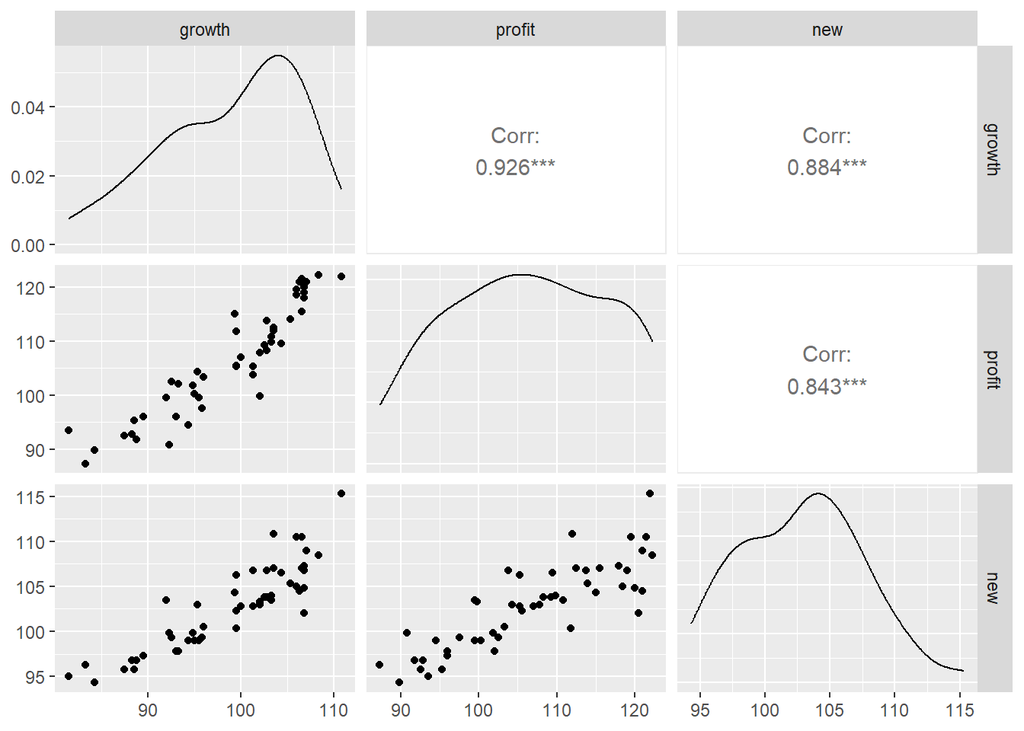

```r
# install.packages("GGally")
library(GGally)
ggpairs(sales_X)
```

Berdasarkan plot berpasangan, terlihat bahwa terjadi multikolinearitas antar peubah X. Namun, karena berdasarkan koefisien korelasi yang dihasilkan diperoleh multikolinearitas yang tidak sempurna (|korelasi| < 1), maka dalam contoh ini kita lanjutkan saja dan diabaikan dulu.

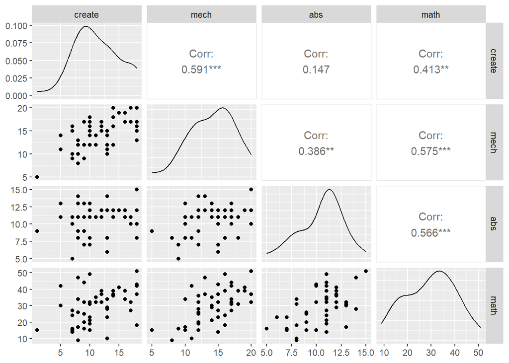

```r
ggpairs(sales_Y)
```

Berdasarkan plot di atas, diperoleh bahwa tidak terjadi multikolinearitas antar peubah Y.

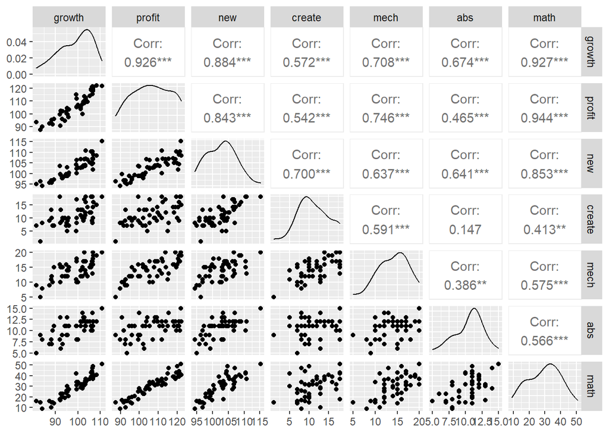

```r
ggpairs(data_sales)
```

Uji normalitas ganda dilakukan dengan:

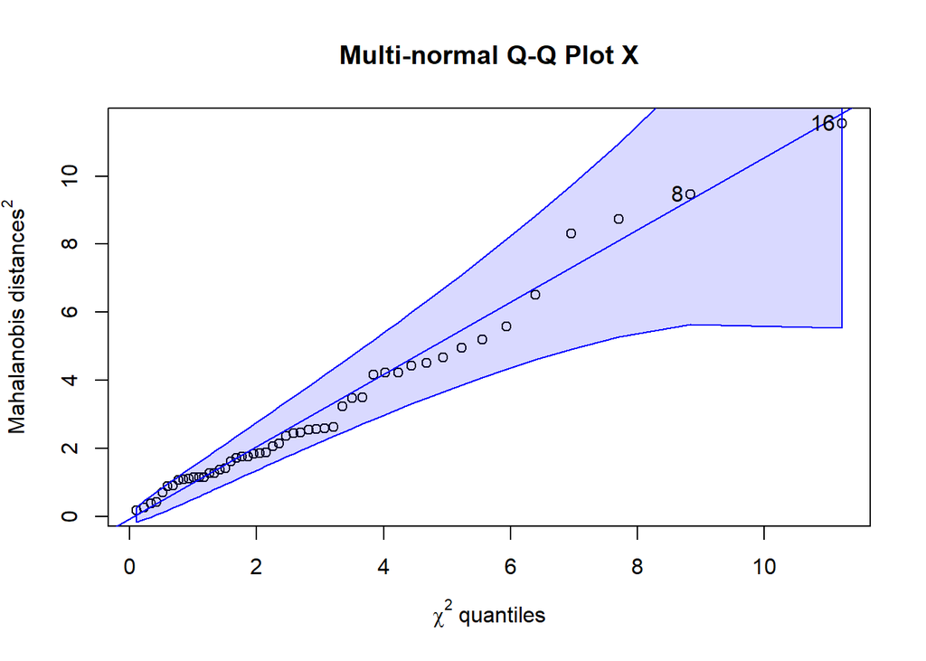

```
## [1] 16  8
```

```r
# install.packages("RVAideMemoire")
library(RVAideMemoire)
mqqnorm(sales_X, main = "Multi-normal Q-Q Plot X")
```

Berdasarkan QQ-plot normalitas ganda peubah X, diperoleh titik-titik menyebar di sekitar garis diagonal sehingga disimpulkan bahwa gugus peubah X menyebar secara normal ganda.

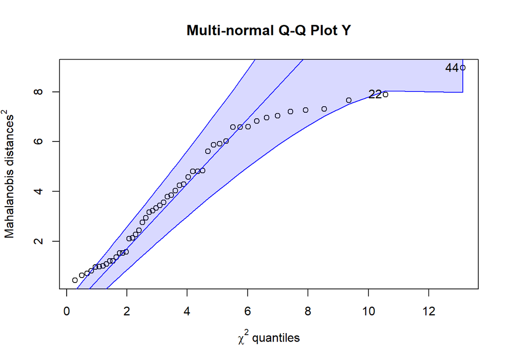

```
## [1] 44 22
```

```r
mqqnorm(sales_Y, main = "Multi-normal Q-Q Plot Y")
```

Berdasarkan QQ-plot normalitas ganda peubah Y, terdapat titik-titik yang tidak menyebar di sekitar garis diagonal sehingga disimpulkan bahwa gugus peubah Y belum menyebar secara normal ganda.

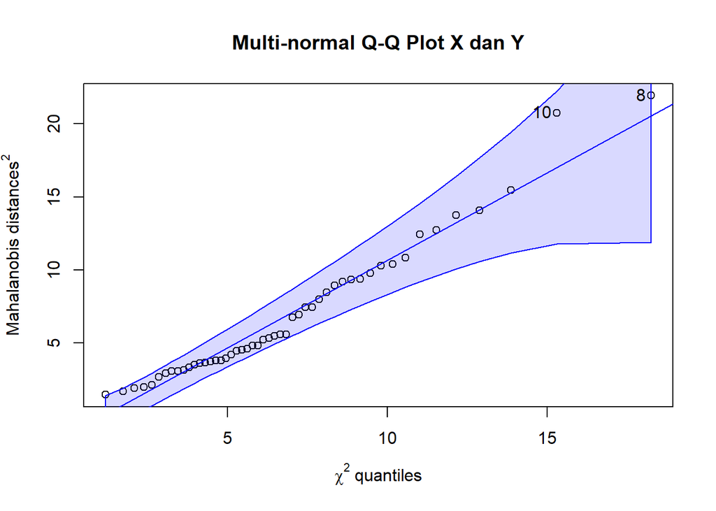

```
## [1]  8 10
```

```r
mqqnorm(cbind(sales_X, sales_Y), main = "Multi-normal Q-Q Plot X dan Y")
```

Berdasarkan QQ-plot normalitas ganda peubah X dan Y, diperoleh bahwa titik-titik menyebar di sekitar garis diagonal sehingga disimpulkan bahwa gugus peubah X dan Y secara bersama-sama sudah menyebar secara normal ganda.  
### Korelasi antar peubah

Periksa korelasi antar **X** dan **Y** :

```r
# install.packages("CCA")
library(CCA)
correls_XY <- matcor(sales_X, sales_Y)
```

Korelasi antar **X** :

```r
kable(correls_XY$Xcor)
```

|  | growth | profit | new |
| --- | --- | --- | --- |
| growth | 1.0000000 | 0.9260758 | 0.8840023 |
| profit | 0.9260758 | 1.0000000 | 0.8425232 |
| new | 0.8840023 | 0.8425232 | 1.0000000 |

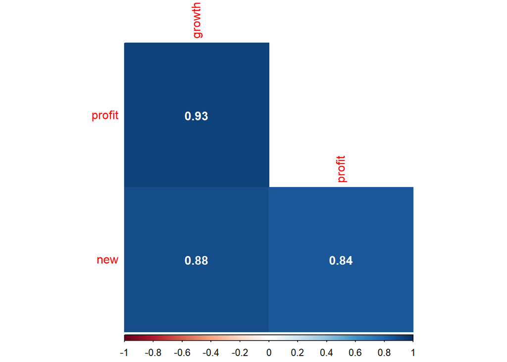

```r
library(corrplot)
corrplot(correls_XY$Xcor, method = "color", addCoef.col ='white', is.cor = T, type = "lower", diag = F)
```

- Besarnya korelasi antara X1 dan X2, X1 dan X3, serta X2 dan X3 secara berurutan adalah 0.9261, 0.8840, dan 0.8425.
- Hasil ini menunjukkan bahwa ada hubungan linear yang erat antar anggota dalam gugus peubah Sales Performance (X) karena mendekati 1 dan arahnya positif.

Korelasi antar **Y** :

```r
kable(correls_XY$Ycor)
```

|  | create | mech | abs | math |
| --- | --- | --- | --- | --- |
| create | 1.0000000 | 0.5907360 | 0.1469074 | 0.4126395 |
| mech | 0.5907360 | 1.0000000 | 0.3859502 | 0.5745533 |
| abs | 0.1469074 | 0.3859502 | 1.0000000 | 0.5663721 |
| math | 0.4126395 | 0.5745533 | 0.5663721 | 1.0000000 |

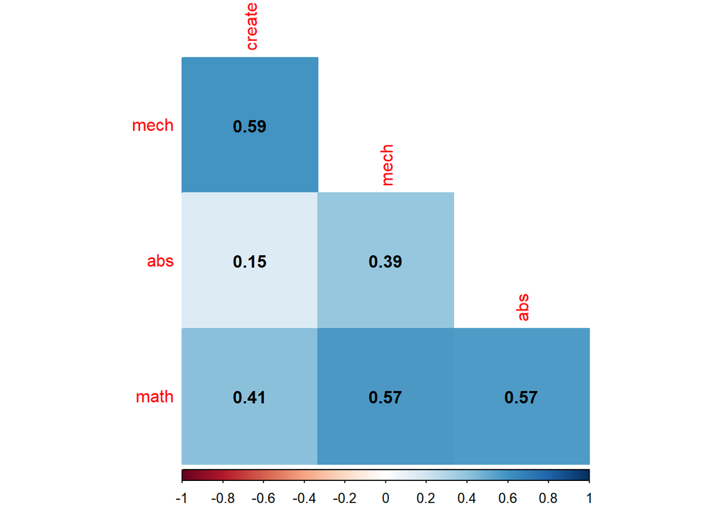

```r
corrplot(correls_XY$Ycor, method = "color", addCoef.col ='black', is.cor = T, type = "lower", diag = F)
```

- Korelasi antar anggota dalam gugus peubah Y cenderung lebih kecil dibandingkan besaran korelasi anggota dalam gugus peubah X.
- Semua nilai korelasi nya kurang dari 0.6.
- Korelasi tertinggi dimiliki hubungan peubah Creativity (Y1) dan Mechanical Reasoning (Y2) sebesar 0.59 dan terendah sebesar 0.1469 yang merupakan hubungan antar Creativity (Y1) dan Abstract Reasoning (Y3).

Korelasi antar X dan Y :

```r
kable(correls_XY$XYcor)
```

|  | growth | profit | new | create | mech | abs | math |
| --- | --- | --- | --- | --- | --- | --- | --- |
| growth | 1.0000000 | 0.9260758 | 0.8840023 | 0.5720363 | 0.7080738 | 0.6744073 | 0.9273116 |
| profit | 0.9260758 | 1.0000000 | 0.8425232 | 0.5415080 | 0.7459097 | 0.4653880 | 0.9442960 |
| new | 0.8840023 | 0.8425232 | 1.0000000 | 0.7003630 | 0.6374712 | 0.6410886 | 0.8525682 |
| create | 0.5720363 | 0.5415080 | 0.7003630 | 1.0000000 | 0.5907360 | 0.1469074 | 0.4126395 |
| mech | 0.7080738 | 0.7459097 | 0.6374712 | 0.5907360 | 1.0000000 | 0.3859502 | 0.5745533 |
| abs | 0.6744073 | 0.4653880 | 0.6410886 | 0.1469074 | 0.3859502 | 1.0000000 | 0.5663721 |
| math | 0.9273116 | 0.9442960 | 0.8525682 | 0.4126395 | 0.5745533 | 0.5663721 | 1.0000000 |

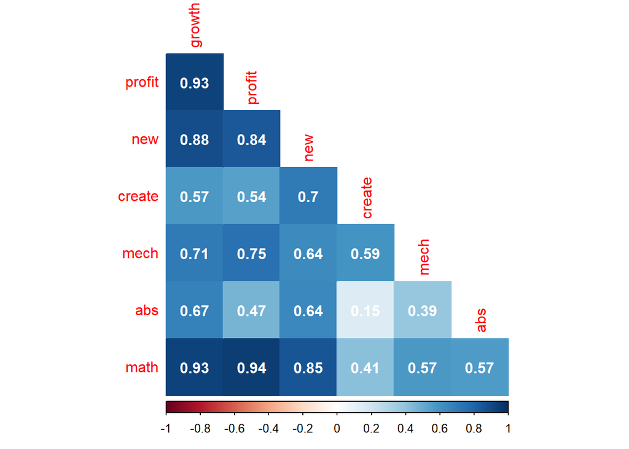

```r
corrplot(correls_XY$XYcor, method = "color", addCoef.col ='white', is.cor = T, type = "lower", diag = F)
```

- Hasil di atas memperlihatkan bahwa Sales Growth (X1), Sales Profitability (X2) dan New Acount Sales (X3) memiliki hubungan linear yang sangat kuat dengan mathematics (Y4).
- Hubungan yang cukup kuat juga terlihat pada hubungan peubah X (X1,X2,X3) dengan mechanical reasoning (Y2).
- Sedangkan tingkat hubungan linear antar peubah X dengan creativity (Y1) dan abstract reasoning (Y3) relatif rendah.

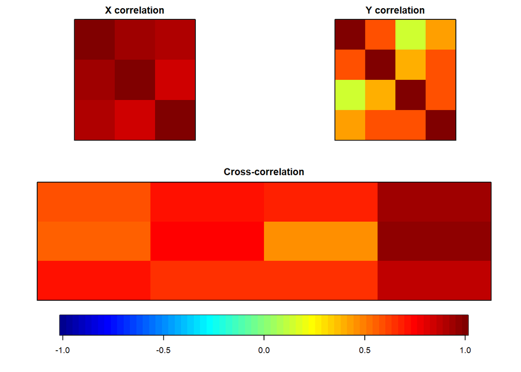

```r
img.matcor(correls_XY, type = 2)
```

### Korelasi kanonik

```r
# install.packages("candisc")
library(candisc)
cca1 <- cancor(sales_X, sales_Y)
summary(cca1)
```

```
##
## Canonical correlation analysis of:
##   3   X  variables:  growth, profit, new
##   with    4   Y  variables:  create, mech, abs, math
##
##     CanR CanRSQ   Eigen percent    cum                          scree
## 1 0.9945 0.9890 89.8745 96.2097  96.21 ******************************
## 2 0.8781 0.7711  3.3682  3.6056  99.82 *
## 3 0.3836 0.1472  0.1725  0.1847 100.00
##
## Test of H0: The canonical correlations in the
## current row and all that follow are zero
##
##      CanR LR test stat approx F numDF  denDF   Pr(> F)
## 1 0.99448      0.00215   87.392    12 114.06 < 2.2e-16 ***
## 2 0.87811      0.19524   18.526     6  88.00 8.247e-14 ***
## 3 0.38361      0.85285      NaN     2    NaN       NaN
## ---
## Signif. codes:  0 '***' 0.001 '**' 0.01 '*' 0.05 '.' 0.1 ' ' 1
##
## Raw canonical coefficients
##
##    X  variables:
##            Xcan1    Xcan2    Xcan3
## growth -0.062378 -0.17407  0.37715
## profit -0.020926  0.24216 -0.10352
## new    -0.078258 -0.23829 -0.38342
##
##    Y  variables:
##            Ycan1     Ycan2     Ycan3
## create -0.069748 -0.192391 -0.246557
## mech   -0.030738  0.201574  0.141895
## abs    -0.089564 -0.495763  0.280224
## math   -0.062830  0.068316 -0.011333
```

atau dapat ditemukan dengan menggunakan *package* `CCA`:

```r
library(CCA)
cc1 <- cc(sales_X, sales_Y)
cc1$cor
```

```
## [1] 0.9944827 0.8781065 0.3836057
```

- Korelasi kanonik pertama (korelasi antara pasangan pertama dari kanonik) adalah sebesar 0.994483.
- Nilai ini merepresentasikan korelasi tertinggi yang mungkin terjadi antara beberapa kombinasi linear dari *sales performance* dan beberapa kombinasi linear dari *Intelligence Test Score*.
- Proporsi keragaman menunjukkan baik tidaknya peubah kanonik yang dipilih untuk menerangkan keragaman asal.
- Semakin besar nilai proporsi keragaman maka semakin baik peubah-peubah kanonik yang dipilih menerangkan keragaman asal. Proporsi keragaman untuk memilih jumlah peubah kanonik yang tepat digunakan untuk menjelaskan hubungan antara gugus peubah dependen dengan independen.
- Berdasarkan kontribusi keragaman yang dijelaskan oleh fungsi kanonik terlihat fungsi kanonik pertama menjelaskan kergaman total sebesar 96.21%, sedangkan yang kedua 3,61%, dan ketiga 0,18%.
- Berdasarkan proprosi keragaman diatas, dengan menggunakan kriteria batasan minimal memiliki kontribusi keragaman 70% (Mattjik dan Sumertajaya 2011), maka cukup mengambil fungsi kanonik yang pertama saja.
- Korelasi kanonik yang pertama dan kedua berbeda nyata dengan nol pada taraf nyata 1% (Pr < α, dengan α = 0.01).
- Sedangkan korelasi kanonik yang ketiga tidak berbeda nyata dengan nol pada taraf nyata 1%.
- Hal ini berarti korelasi kanonik yang dapat digunakan untuk menjelaskan hubungan antar gugus peubah *Sales Performance* dengan *Intelligence Test Score* adalah dua korelasi kanonik yang pertama.

### Koefisien korelasi kanonik mentah

Koefisien kanonik *raw* / mentah untuk peubah *sales performance*:

```r
cc1[3:4]
```

```
## $xcoef
##               [,1]       [,2]       [,3]
## growth -0.06237788 -0.1740703  0.3771529
## profit -0.02092564  0.2421641 -0.1035150
## new    -0.07825817 -0.2382940 -0.3834151
##
## $ycoef
##               [,1]        [,2]        [,3]
## create -0.06974814 -0.19239132 -0.24655659
## mech   -0.03073830  0.20157438  0.14189528
## abs    -0.08956418 -0.49576326  0.28022405
## math   -0.06282997  0.06831607 -0.01133259
```

Interpretasi koefisien di atas mirip dengan interpretasi koefisien regresi, di mana:

- Peningkatan nilai Sales Growth (X1) akan menurunkan variansi kanonik pertama dari gugus peubah *sales performance* sebesar 0.0624 dengan peubah lainnya dianggap konstan.
- Peningkatan nilai Profitability (X2) akan menurunkan variansi kanonik pertama dari gugus peubah *sales performance* sebesar 0.0209 dengan peubah lainnya dianggap konstan.
- dan seterusnya.

### Menghitung *loading kanonik*

Fungsi `comput()` digunakan untuk menghitung loading kanonik, yang digunakan untuk menampilkan korelasi peubah dengan fungsi kanonik sebagai berikut:

```r
cc1_comp <- comput(sales_X, sales_Y, cc1)
```

- Korelasi X dengan fungsi kanonik X:

```r
cc1_comp$corr.X.xscores
```

```
##              [,1]          [,2]         [,3]
## growth -0.9798776  0.0006477883  0.199598477
## profit -0.9464085  0.3228847489 -0.007504408
## new    -0.9518620 -0.1863009724 -0.243414776
```

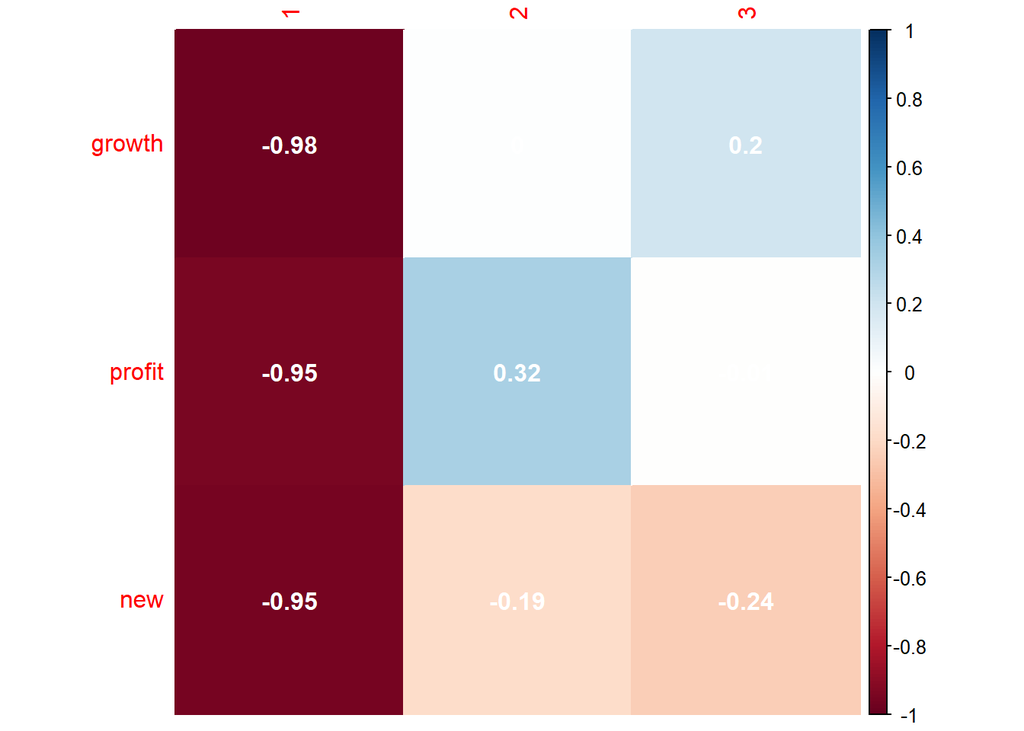

```r
corrplot(cc1_comp$corr.X.xscores, method = "color", addCoef.col ='white', is.cor = T)
```

Diperoleh bahwa untuk fungsi kanonik peubah *sales performance* peubah-peubah yang berhubungan paling erat dengan fungsi kanonik pertama adalah Sales Growth (X1), sedangkan terhadap fungsi kanonik kedua yaitu Sales Profitability (X2).

- Korelasi Y dengan fungsi kanonik Y:

```r
cc1_comp$corr.Y.yscores
```

```
##              [,1]       [,2]        [,3]
## create -0.6383313 -0.2156981 -0.65140953
## mech   -0.7211626  0.2375644  0.06773775
## abs    -0.6472493 -0.5013329  0.57422365
## math   -0.9440859  0.1975329  0.09422619
```

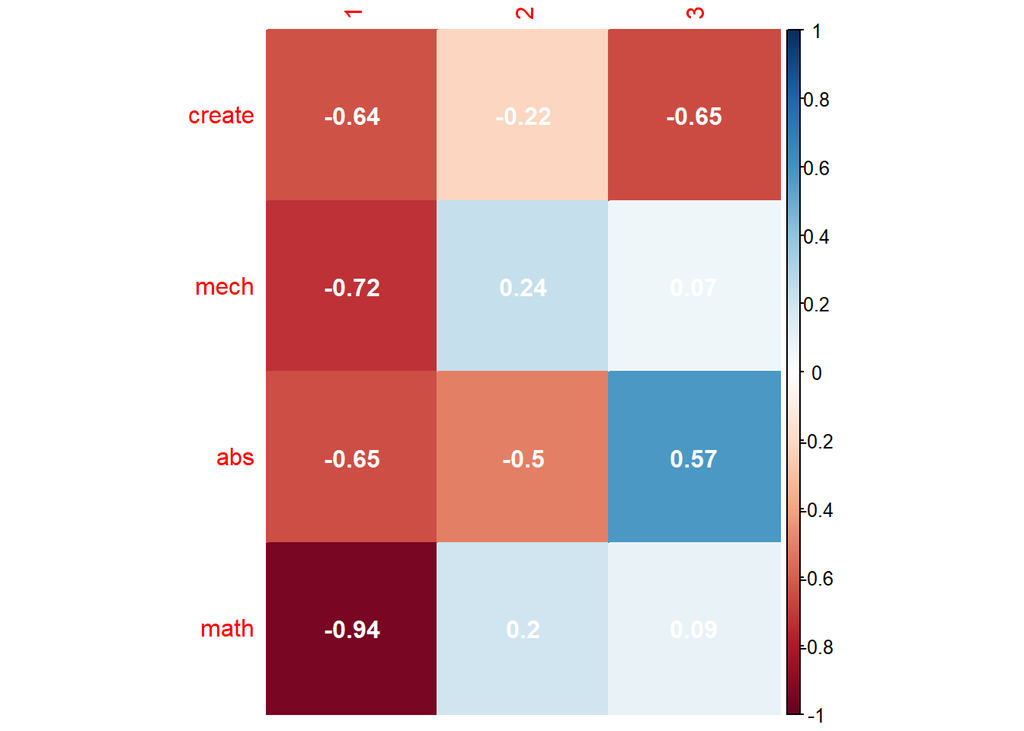

```r
corrplot(cc1_comp$corr.Y.yscores, method = "color", addCoef.col ='white', is.cor = T)
```

Untuk fungsi kanonik peubah *Intelligence Test Score* terlihat bahwa peubah-peubah yang berhubungan paling erat dengan fungsi kanonik pertama yaitu Mathematic (Y4) kemudian Mechanical Reasoning (Y2), sedangkan terhadap fungsi kanonik kedua yaitu Abstract Reasoning (Y3).

- Korelasi silang X dengan fungsi kanonik Y:

```r
cc1_comp$corr.X.yscores
```

```
##              [,1]          [,2]         [,3]
## growth -0.9744713  0.0005688272  0.076567107
## profit -0.9411869  0.2835272081 -0.002878734
## new    -0.9466102 -0.1635921013 -0.093375287
```

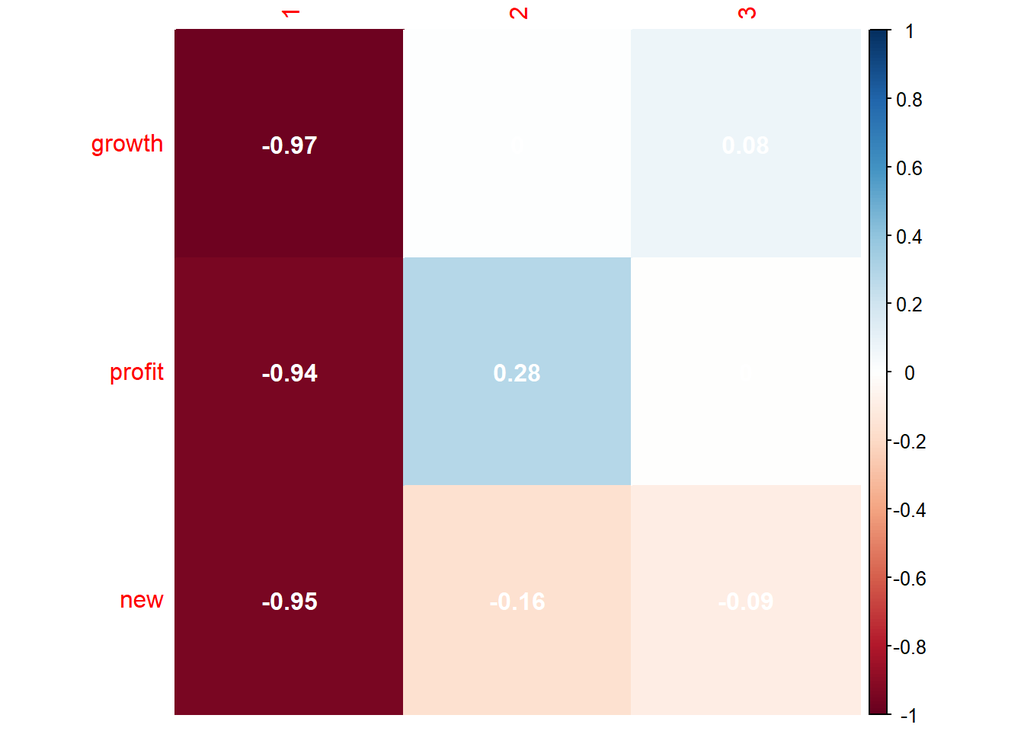

```r
corrplot(cc1_comp$corr.X.yscores, method = "color", addCoef.col ='white', is.cor = T)
```

Korelasi silang antar peubah-peubah dependen terhadap fungsi kanonik peubah independen memberikah hasil bahwa yang berhubungan paling erat dengan fungsi kanonik pertama adalah Sales Growth (X1), dan dengan fungsi kanonik kedua adalah Sales Profitability (X2).

- Korelasi silang Y dengan fungsi kanonik X:

```r
cc1_comp$corr.Y.xscores
```

```
##              [,1]       [,2]        [,3]
## create -0.6348095 -0.1894059 -0.24988439
## mech   -0.7171837  0.2086069  0.02598458
## abs    -0.6436782 -0.4402237  0.22027544
## math   -0.9388771  0.1734549  0.03614570
```

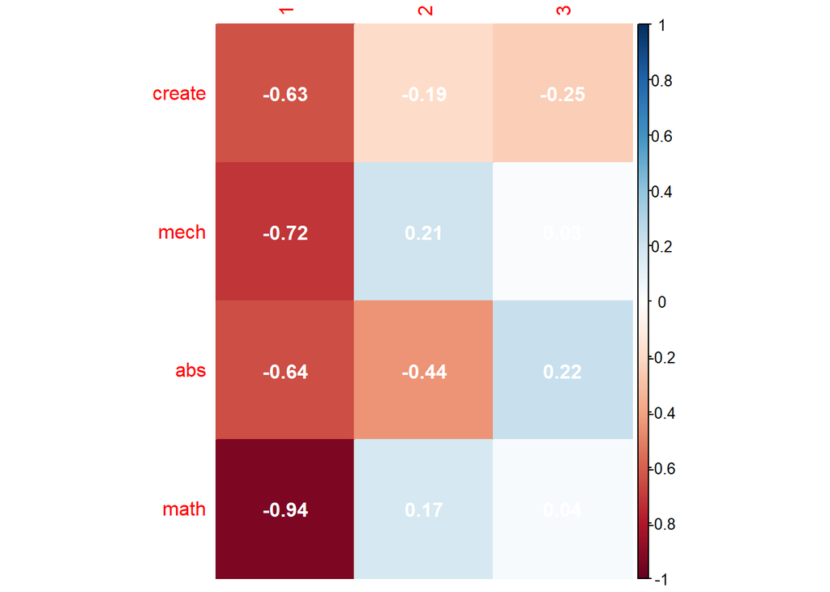

```r
corrplot(cc1_comp$corr.Y.xscores, method = "color", addCoef.col ='white', is.cor = T)
```

Sedangkan korelasi silang antar peubah-peubah independen terhadap fungsi kanonik peubah dependen memberikah hasil bahwa yang berhubungan paling erat dengan fungsi kanonik pertama adalah Mathematic (Y4), dan dengan fungsi kanonik kedua adalah Abstract Reasoning (Y3).

### Uji signifikansi korelasi kanonik

```r
rho <- cc1$cor
n <- dim(sales_X)[1]
p <- length(sales_X)
q <- length(sales_Y)
```

```r
# install.packages("CCP")
library(CCP)
p.asym(rho, n, p, q, tstat = "Wilks")
```

```
## Wilks' Lambda, using F-approximation (Rao's F):
##                 stat    approx df1      df2      p.value
## 1 to 3:  0.002148472 87.391525  12 114.0588 0.000000e+00
## 2 to 3:  0.195241267 18.526265   6  88.0000 8.248957e-14
## 3 to 3:  0.852846693  3.882233   2  45.0000 2.783536e-02
```

```r
p.asym(rho, n, p, q, tstat = "Hotelling")
```

```
##  Hotelling-Lawley Trace, using F-approximation:
##                stat     approx df1 df2    p.value
## 1 to 3:  93.4151751 324.358247  12 125 0.00000000
## 2 to 3:   3.5407119  25.768514   6 131 0.00000000
## 3 to 3:   0.1725437   3.939747   2 137 0.02169625
```

```r
p.asym(rho, n, p, q, tstat = "Pillai")
```

```
##  Pillai-Bartlett Trace, using F-approximation:
##               stat   approx df1 df2      p.value
## 1 to 3:  1.9072202 19.63454  12 135 0.000000e+00
## 2 to 3:  0.9182244 10.36532   6 141 1.680060e-09
## 3 to 3:  0.1471533  3.79122   2 147 2.480577e-02
```

```r
p.asym(rho, n, p, q, tstat = "Roy")
```

```
##  Roy's Largest Root, using F-approximation:
##               stat   approx df1 df2 p.value
## 1 to 1:  0.9889958 1011.088   4  45       0
##
##  F statistic for Roy's Greatest Root is an upper bound.
```

Secara umum, banyak fungsi/dimensi kanonik sama dengan jumlah peubah dalam himpunan yang lebih kecil, namun banyak dimensi yang signifikan mungkin lebih kecil lagi. Dimensi kanonik, juga dikenal sebagai fungsi kanonik, adalah peubah laten yang mirip dengan faktor-faktor yang diperoleh dalam analisis faktor. Untuk model khusus ini terdapat tiga dimensi kanonik.

Dari hasil di atas diperoleh bahwa keempat pengujian menunjukkan bahwa pada fungsi/dimensi kanonik pertama, semuanya signifikan pada taraf nyata 5%. Artinya, minimal ada satu korelasi kanonik yang nyata. Selanjutnya dilanjutkan dengan uji parsial.

```r
cca1
```

```
##
## Canonical correlation analysis of:
##   3   X  variables:  growth, profit, new
##   with    4   Y  variables:  create, mech, abs, math
##
##     CanR CanRSQ   Eigen percent    cum                          scree
## 1 0.9945 0.9890 89.8745 96.2097  96.21 ******************************
## 2 0.8781 0.7711  3.3682  3.6056  99.82 *
## 3 0.3836 0.1472  0.1725  0.1847 100.00
##
## Test of H0: The canonical correlations in the
## current row and all that follow are zero
##
##      CanR LR test stat approx F numDF  denDF   Pr(> F)
## 1 0.99448      0.00215   87.392    12 114.06 < 2.2e-16 ***
## 2 0.87811      0.19524   18.526     6  88.00 8.247e-14 ***
## 3 0.38361      0.85285      NaN     2    NaN       NaN
## ---
## Signif. codes:  0 '***' 0.001 '**' 0.01 '*' 0.05 '.' 0.1 ' ' 1
```

Berdasarkan LR test, diperoleh bahwa korelasi kanonik yang pertama dan kedua berbeda nyata dengan nol pada taraf nyata 1% (Pr < α, dengan α=0.01). Sedangkan korelasi kanonik yang ketiga tidak berbeda nyata dengan nol pada taraf nyata 1%. Hal ini berarti korelasi kanonik yang dapat digunakan untuk menjelaskan hubungan antar gugus peubah *Sales Performance* dengan *Intelligence Test Score* adalah dua korelasi kanonik yang pertama.

### Menghitung koefisien korelasi kanonik terstandardisasi

```r
coef_X <- diag(sqrt(diag(cov(sales_X))))
coef_X %*% cc1$xcoef
```

```
##            [,1]      [,2]      [,3]
## [1,] -0.4576880 -1.277214  2.767301
## [2,] -0.2118578  2.451745 -1.048019
## [3,] -0.3687696 -1.122893 -1.806735
```

- Koefisien kanonik untuk fungsi kanonik dependen (*sales performance*) menunjukkan bahwa urutan kontribusi relatif peubah-peubah *sales performance* (X) terhadap variate/fungsi kanonik pertama adalah Sales Growth (X1), New Account Sales (X3), dan Sales Profitability (X2);
- Urutan kontribusi relatif peubah-peubah X terhadap variate kedua adalah Sales Profitability (X2), Sales Growth (X1), dan New Account Sales (X3).

```r
coef_Y <- diag(sqrt(diag(cov(sales_Y))))
coef_Y %*% cc1$ycoef
```

```
##            [,1]       [,2]       [,3]
## [1,] -0.2755155 -0.7599743 -0.9739351
## [2,] -0.1040424  0.6822849  0.4802843
## [3,] -0.1916330 -1.0607433  0.5995720
## [4,] -0.6620838  0.7198947 -0.1194195
```

- Urutan kontribusi relatif peubah-peubah *Intelligence Test Score* (Y) terhadap variate pertama adalah Mathematic (Y4), Creativity (Y1), Abstract Reasoning (Y3), dan Mechanical Reasoning (Y2);
- Urutan kontribusi relatif peubah-peubah Y terhadap variate kedua adalah Abstract Reasoning (Y3), Creativity (Y1), Mathematic (Y4), dan Mechanical Reasoning (Y2).

### Peubah Kanonik

Diperoleh beberapa fungsi kanonik berikut:

$V_1 = -0.2755 Y_1 - 0.1040 Y_2 - 0.1916 Y_3 - 0.6621 Y_4$  
$V_2 = -0.7600 Y_1 + 0.6823 Y_2 - 1.0607 Y_3 + 0.7199 Y_4$

## Studi Kasus - 2

Seorang peneliti ingin melakukan suatu eksperimen yang melibatkan suatu reaksi kimia dengan 3 peubah independen dan 3 peubah dependen (Box dan Youle, 1955; Rencher, 2002). Peubah-peubah tersebut adalah sebagai berikut :  
X1 : temperature  
X2 : concentration  
X3 : time  
Y1 : percentage of unchanged starting material  
Y2 : percentage converted to the desired product  
Y3 : percentage of unwanted by-product

Lakukan analisis korelasi kanonik terhadap data berikut:

### Import data

```r
# install.packages("ACSWR")
library(ACSWR)
data(chemicaldata)
kable(head(chemicaldata))
```

| y1 | y2 | y3 | x1 | x2 | x3 |
| --- | --- | --- | --- | --- | --- |
| 41.5 | 45.9 | 11.2 | 162 | 23 | 3 |
| 33.8 | 53.3 | 11.2 | 162 | 23 | 8 |
| 27.7 | 57.5 | 12.7 | 162 | 30 | 5 |
| 21.7 | 58.8 | 16.0 | 162 | 30 | 8 |
| 19.9 | 60.6 | 16.2 | 172 | 25 | 5 |
| 15.0 | 58.0 | 22.6 | 172 | 25 | 8 |

```r
X <- chemicaldata[,4:6]
Y <- chemicaldata[,1:3]
```

### Periksa asumsi

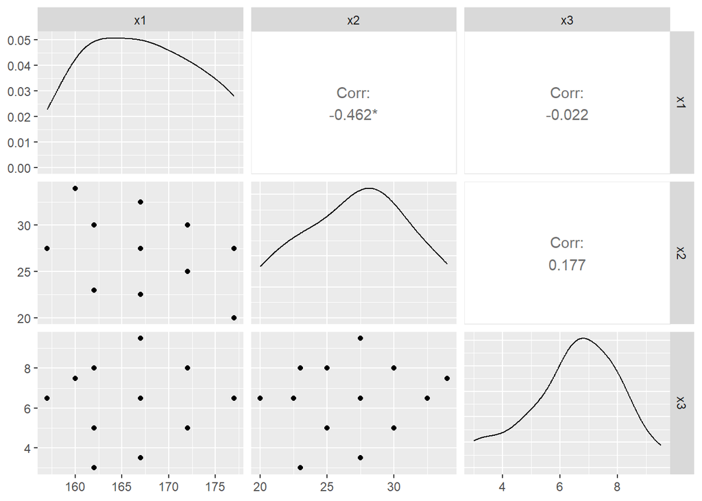

```r
ggpairs(X)
```

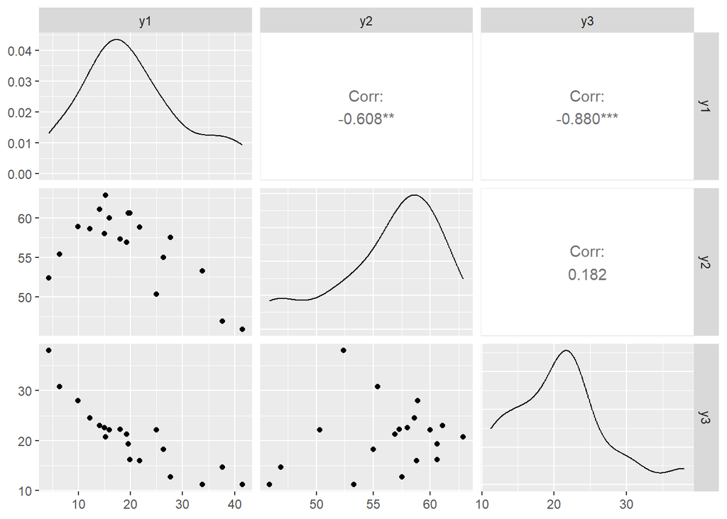

```r
ggpairs(Y)
```

Sebagaimana plot yang diperoleh, pada gugus peubah Y terdapat peubah Y1 dan Y3 yang berkorelasi kuat dan berpotensi menyebabkan multikolinearitas.

```r
correl <- matcor(X, Y)
```

Berikut merupakan ilai korelasi pearson antar peubah X, antar peubah Y, dan korelasi silang antara peubah X dengan peubah Y.

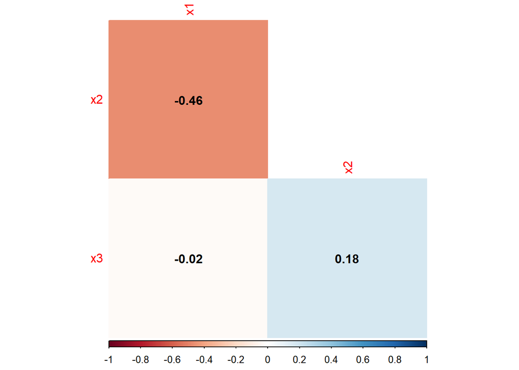

```r
corrplot(correl$Xcor, method = "color", addCoef.col ='black', is.cor = T, type = "lower", diag = F)
```

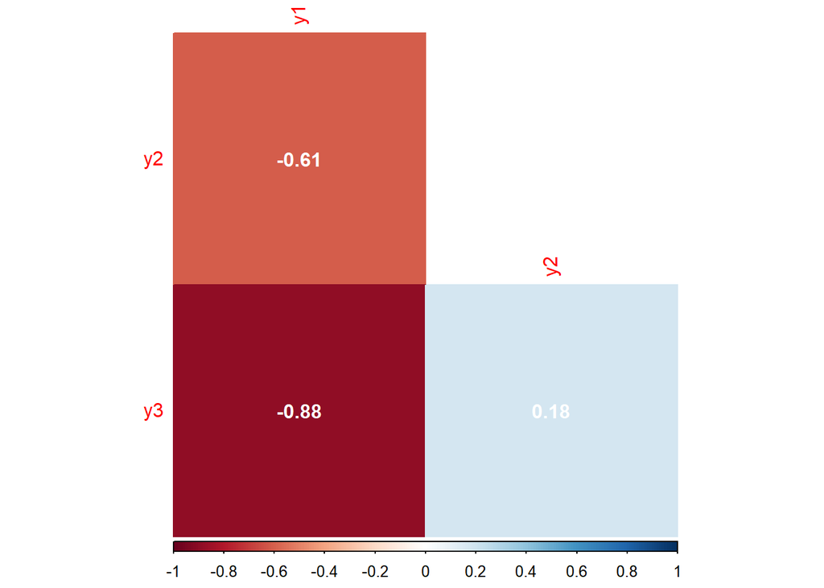

```r
corrplot(correl$Ycor, method = "color", addCoef.col ='white', is.cor = T, type = "lower", diag = F)
```

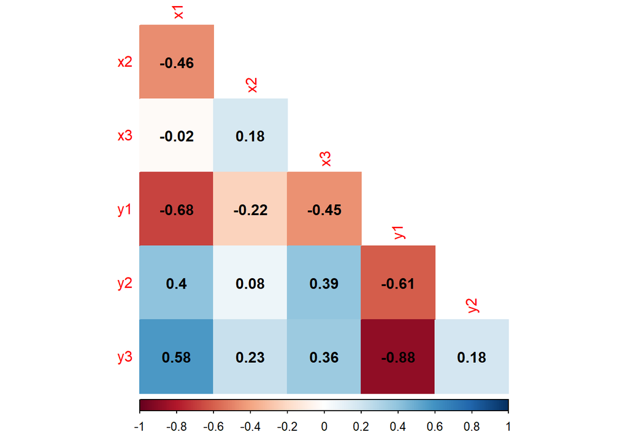

```r
corrplot(correl$XYcor, method = "color", addCoef.col ='black', is.cor = T, type = "lower", diag = F)
```

### Korelasi Kanonik

```r
cca2 <- candisc::cancor(X,Y)
summary(cca2)
```

```
##
## Canonical correlation analysis of:
##   3   X  variables:  x1, x2, x3
##   with    3   Y  variables:  y1, y2, y3
##
##      CanR   CanRSQ     Eigen  percent    cum                          scree
## 1 0.98153 0.963395 26.318349 99.60771  99.61 ******************************
## 2 0.30199 0.091200  0.100353  0.37981  99.99
## 3 0.05733 0.003287  0.003298  0.01248 100.00
##
## Test of H0: The canonical correlations in the
## current row and all that follow are zero
##
##      CanR LR test stat approx F numDF  denDF   Pr(> F)
## 1 0.98153      0.03316  10.7870     9 31.789 1.884e-07 ***
## 2 0.30199      0.90581   0.3549     4 28.000    0.8384
## 3 0.05733      0.99671   0.0495     1 15.000    0.8270
## ---
## Signif. codes:  0 '***' 0.001 '**' 0.01 '*' 0.05 '.' 0.1 ' ' 1
##
## Raw canonical coefficients
##
##    X  variables:
##       Xcan1    Xcan2     Xcan3
## x1 -0.16062 -0.06944 -0.049094
## x2 -0.14861 -0.12159  0.191179
## x3 -0.21568  0.58392  0.037688
##
##    Y  variables:
##       Ycan1   Ycan2   Ycan3
## y1 0.170794 0.62594 0.37732
## y2 0.069097 0.72999 0.21730
## y3 0.085825 0.71274 0.53900
```

Kontribusi korelasi kanonik terbesar ditunjukkan pada fungsi kanonik pertama. Artinya untuk menerangkan keragaman total cukup mengambil fungsi kanonik pertama saja.

Uji hipotesis menunjukkan bahwa korelasi kanonik pertama berbeda nyata. Artinya korelasi kanonik yang dapat digunakan untuk menjelaskan hubungan antar gugus peubah X dan Y adalah satu korelasi kanonik.

```r
coef_X <- diag(sqrt(diag(cov(X))))
coef_X %*% cca2$coef$X
```

```
##           Xcan1      Xcan2       Xcan3
## [1,] -0.9988316 -0.4318281 -0.30530044
## [2,] -0.6296241 -0.5151350  0.80998368
## [3,] -0.3522073  0.9535361  0.06154487
```

```r
coef_Y <- diag(sqrt(diag(cov(Y))))
coef_Y %*% cca2$coef$Y
```

```
##          Ycan1    Ycan2    Ycan3
## [1,] 1.7019208 6.237351 3.759917
## [2,] 0.3259174 3.443189 1.024953
## [3,] 0.5774680 4.795627 3.626580
```

Diperoleh fungsi kanonik berikut:

$U = -0.9988 X_1 - 0.6296 X_2 - 0.3522 X_3$  
$V = 1.7019 Y_1 + 0.3259 Y_2 + 0.5775 Y_3$

### Korelasi dengan fungsi kanonik

#### Korelasi X dan fungsi kanonik X (U):

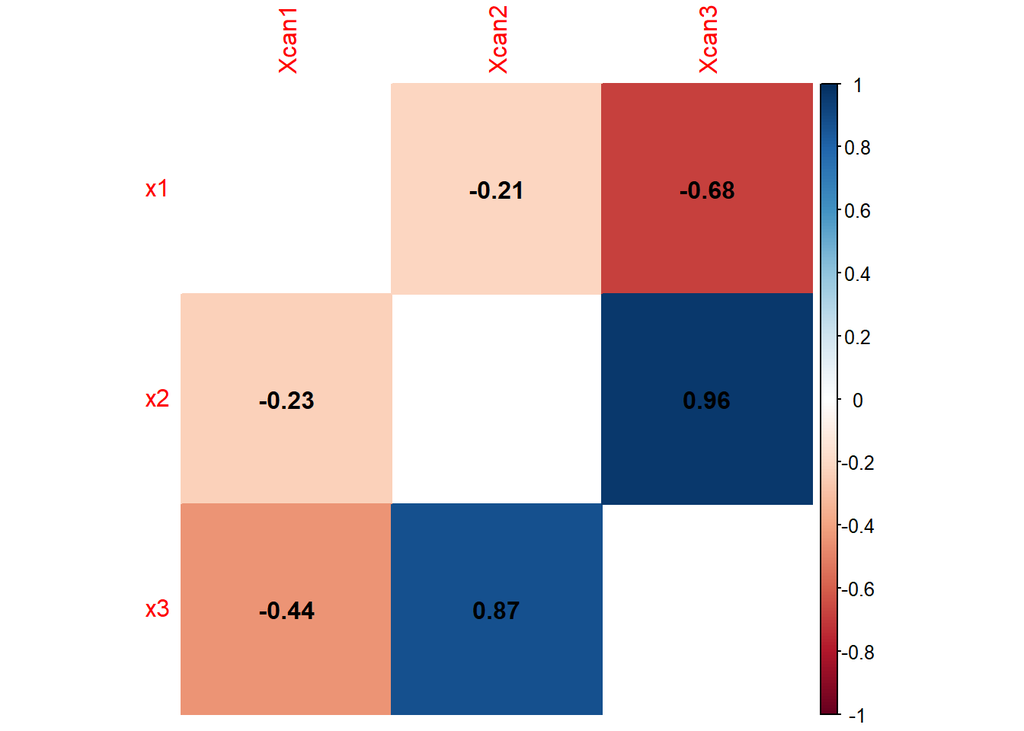

```r
corrplot(cca2$structure$X.xscores, method = "color", addCoef.col ='black', is.cor = T, diag = F)
```

#### Korelasi Y dan fungsi kanonik Y (V):

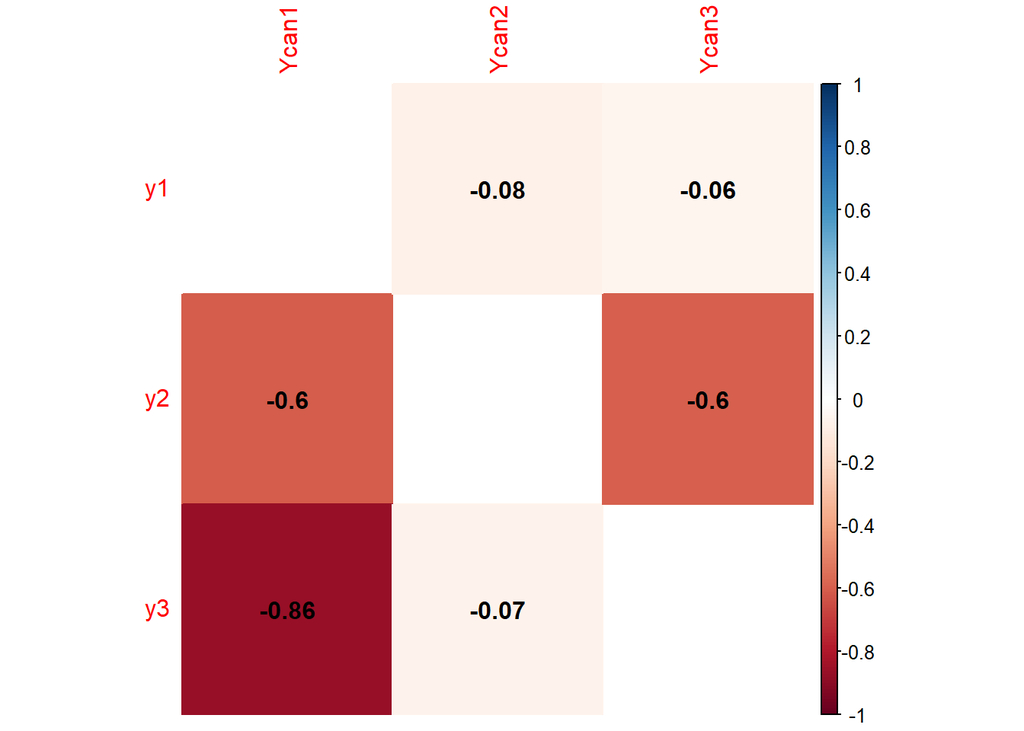

```r
corrplot(cca2$structure$Y.yscores, method = "color", addCoef.col ='black', is.cor = T, diag = F)
```

#### Korelasi X dan V :

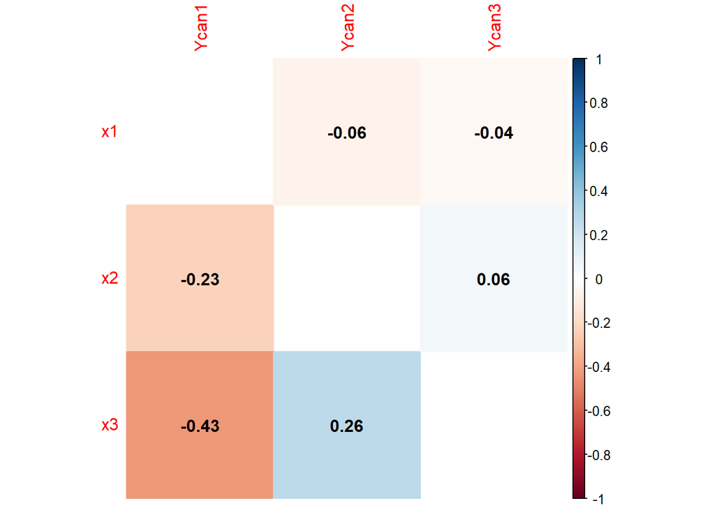

```r
corrplot(cca2$structure$X.yscores, method = "color", addCoef.col ='black', is.cor = T, diag = F)
```

#### Korelasi Y dan U:

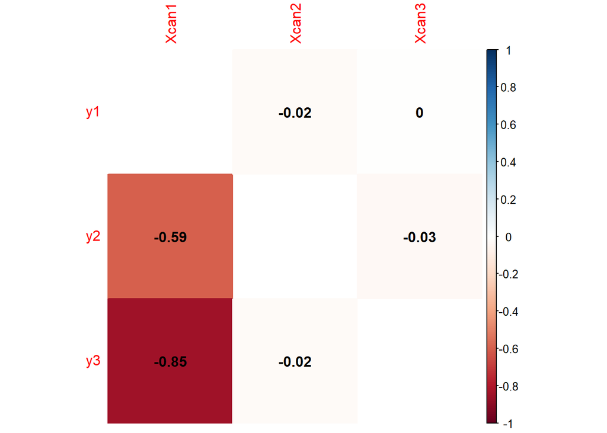

```r
corrplot(cca2$structure$Y.xscores, method = "color", addCoef.col ='black', is.cor = T, diag = F)
```

# Pertemuan 14 Analisis Multidemensional scaling

## Metode MDS

1. **Metric / Classical Multidimensional Scaling**
   - Skala yang digunakan dalam multidimensional scaling metrik adalah skala data interval dan skala data rasio.
   - Dalam prosedur multidimensional scaling metrik hanya menyusun bentuk geometri dari titik-titik objek yang diupayakan sedekat mungkin dengan input jarak yang diberikan.
   - Pada dasarnya, MDS metrik adalah mengubah input jarak kedalam bentuk geometrik sebagai outputnya.
   - Perhitungan jarak dapat dilakukan menggunakan jarak euclid.
2. **Nonmetric Multidimensional Scaling**
   - Multidimesional scaling nonmetrik mengasumsikan bahwa datanya adalah kualitatif (nominal dan ordinal)
   - Mengasumsikan bahwa hanya peringkat jarak antar data yang diketahui
   - Teknik ini lebih fleksibel dan robust dibandingkan MDS Metrik karena dapat digunakan dengan data yang mungkin tidak memenuhi asumsi-asumsi ketat yang diperlukan oleh MDS.
   - Dapat digunakan untuk memvisualisasikan hubungan antar objek yang tidak mudah dilihat pada data aslinya.

### Studi Kasus 1

Diberikan suatu data yang mencantumkan jarak terbang antar sepuluh kota di Amerika Serikat, seperti yang terlihat dalam data berikut.

Data ini dapat dengan mudah dibuat dari peta Amerika Serikat dengan menggunakan penggaris untuk mengukur jarak antar kota-kota tersebut. Namun, terdapat situasi di mana seseorang diberikan hanya data jarak antar kota tersebut dan kemudian diminta untuk membuat peta berdasarkan jarak-jarak ini. Membuat peta berdasarkan data jarak ini merupakan masalah yang lebih sulit. Peta yang akurat harus memperhitungkan hubungan spasial yang sebenarnya antara kota-kota tersebut.

Multidimensional Scaling (MDS) diharapkan dapat menangani masalah ini. MDS adalah teknik analisis multivariat yang bertujuan untuk mereduksi dimensi dari data dengan tetap mempertahankan hubungan atau jarak antar objek.

1. **Menyiapkan data**

Karena data berskala kuantitatif, maka dalam kasus ini dilakukan penskalaan dengan MMDS.

```r
airline_data <- matrix(ncol=10,nrow=10)

colnames(airline_data) <- c("Atlanta","Chicago","Denver","Houston","Los_Angeles","Miami","New_York","San_Francisco","Seattle","Washington_D.C")

rownames(airline_data) <- c("Atlanta","Chicago","Denver","Houston","Los_Angeles","Miami","New_York","San_Francisco","Seattle","Washington_D.C")

airline_data[lower.tri(airline_data)] <- c(587,1212,701,1936,604,748,2139,2182,543,920,940,1745,1188,713,1858,1737,597,879,831,1726,1631,949,1021,1494,1374,968,1420,1645,1891,1220,2339,2451,347,959,2300,1092,2594,2734,923,2571,2408,205,678,2442,2329)

diag(airline_data) <- 0
airline_data <- as.dist(airline_data, diag = TRUE) # membuat data matriks menjadi kelas dist
class(airline_data)
```

```
## [1] "dist"
```

```r
airline_data
```

```
##                Atlanta Chicago Denver Houston Los_Angeles Miami New_York
## Atlanta              0
## Chicago            587       0
## Denver            1212     920      0
## Houston            701     940    879       0
## Los_Angeles       1936    1745    831    1374           0
## Miami              604    1188   1726     968        2339     0
## New_York           748     713   1631    1420        2451  1092        0
## San_Francisco     2139    1858    949    1645         347  2594     2571
## Seattle           2182    1737   1021    1891         959  2734     2408
## Washington_D.C     543     597   1494    1220        2300   923      205
##                San_Francisco Seattle Washington_D.C
## Atlanta
## Chicago
## Denver
## Houston
## Los_Angeles
## Miami
## New_York
## San_Francisco              0
## Seattle                  678       0
## Washington_D.C          2442    2329              0
```

2. **Menghitung koordinat MMDS**

Untuk membentuk koordinat MMDS dengan fungsi `cmdscale()`. Fungsi ini memiliki beberapa argumen:

1. `d` : objek data berformat *dist* (matriks jarak/distance)
2. `k` : maksimum dimensi di mana data akan direpresentasikan, bernilai antara 1 sampai p-1 untuk data berdimensi p
3. `eig` : argumen bertipe boolean untuk menentukan apakah nilai ciri akan dikembalikan

```r
mmds_coord <- cmdscale(airline_data, k = 2, eig = T)
coords <- mmds_coord$points
coords
```

```
##                      [,1]       [,2]
## Atlanta         -718.7594  142.99427
## Chicago         -382.0558 -340.83962
## Denver           481.6023  -25.28504
## Houston         -161.4663  572.76991
## Los_Angeles     1203.7380  390.10029
## Miami          -1133.5271  581.90731
## New_York       -1072.2357 -519.02423
## San_Francisco   1420.6033  112.58920
## Seattle         1341.7225 -579.73928
## Washington_D.C  -979.6220 -335.47281
```

3. **Membentuk plot MMDS**

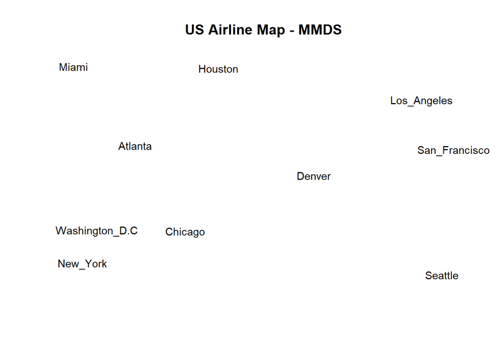

```r
plot(coords[,1], coords[,2], type = "n", xlab = "", ylab = "", axes = FALSE,
     main = "US Airline Map - MMDS")
text(coords[,1], coords[,2], labels(airline_data), cex = 0.9, xpd = TRUE)
```

Grafik hasil menunjukkan bahwa Washington dan New York adalah kota yang berdekatan. Kedua, kita dapat melihat bahwa Los Angeles dan San Francisco berdekatan satu sama lain. Di sisi lain, Miami dan Seattle adalah kota yang paling jauh satu sama lain. Juga, San Francisco terletak jauh dari Miami, New York, dan Washington.

4. **Evaluasi kebaikan MMDS**

```r
#install.packages("seqhandbook")
library(seqhandbook)
stress <- seqmds.stress(airline_data, mmds_coord)
stress
```

```
## [1] 0.203094564 0.003273269
```

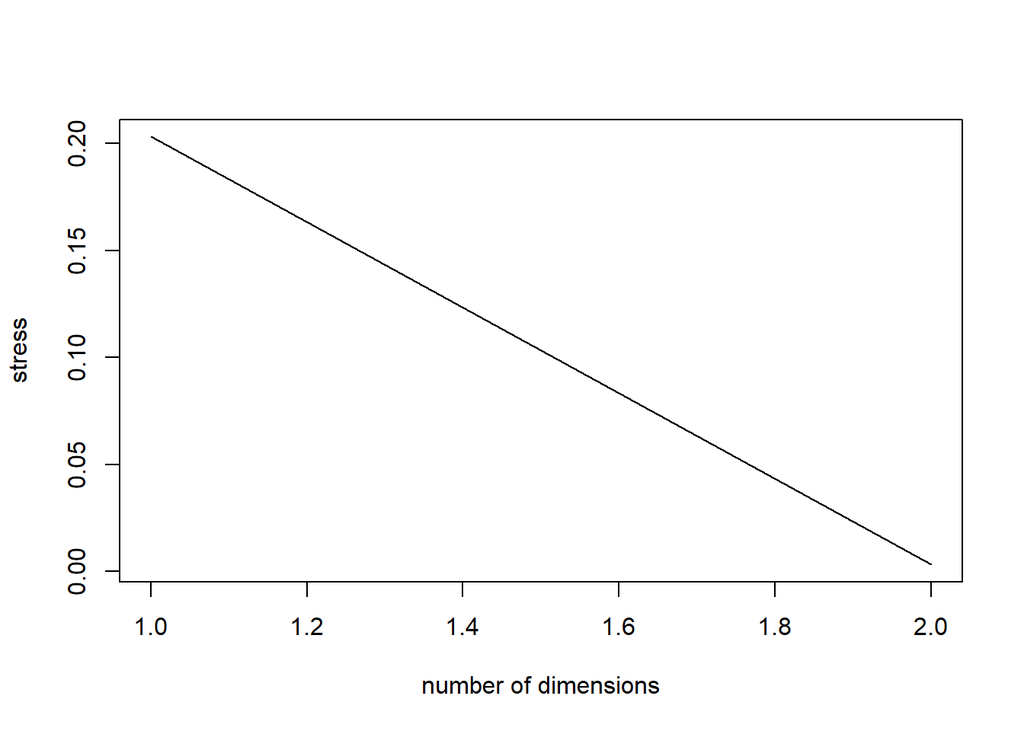

```r
plot(stress, type='l', xlab='number of dimensions', ylab='stress')
```

Diperoleh bahwa dengan memetakan ke dalam 2 dimensi, diperoleh nilai stress sebesar 0.00327 (mendekati nol), artinya penskalaan ini sudah baik.

### Studi Kasus 2

Matriks data yang digunakan dalam analisis ini mewakili jumlah perbedaan yang ada di antara para politisi Perang Dunia II.

1. **Menyiapkan data**

```r
ww_data <- matrix(ncol=12,nrow=12)

colnames(ww_data) <- c("Hitler","Mussolini","Churchill","Eisenhower","Stalin","Attlee","Franco","De_Gaulle","Mao_Tse","Truman","Chamberlain","Tiro")

rownames(ww_data) <- c("Hitler","Mussolini","Churchill","Eisenhower","Stalin","Attlee","Franco","De_Gaulle","Mao_Tse","Truman","Chamberlain","Tiro")

ww_data[lower.tri(ww_data)] <- c(5,11,15,8,17,5,10,16,17,12,16,14,16,13,18,3,11,18,18,14,17,7,11,11,12,5,16,8,10,8,16,16,14,8,17,6,7,12,15,13,11,12,14,16,12,16,12,16,12,9,13,9,17,16,10,12,13,9,11,7,12,17,10,9,11,15)

diag(ww_data) <- 0

class(ww_data)
```

```
## [1] "matrix" "array"
```

```r
ww_data
```

```
##             Hitler Mussolini Churchill Eisenhower Stalin Attlee Franco
## Hitler           0        NA        NA         NA     NA     NA     NA
## Mussolini        5         0        NA         NA     NA     NA     NA
## Churchill       11        14         0         NA     NA     NA     NA
## Eisenhower      15        16         7          0     NA     NA     NA
## Stalin           8        13        11         16      0     NA     NA
## Attlee          17        18        11         16     15      0     NA
## Franco           5         3        12         14     13     16      0
## De_Gaulle       10        11         5          8     11     12      9
## Mao_Tse         16        18        16         17     12     16     17
## Truman          17        18         8          6     14     12     16
## Chamberlain     12        14        10          7     16      9     10
## Tiro            16        17         8         12     12     13     12
##             De_Gaulle Mao_Tse Truman Chamberlain Tiro
## Hitler             NA      NA     NA          NA   NA
## Mussolini          NA      NA     NA          NA   NA
## Churchill          NA      NA     NA          NA   NA
## Eisenhower         NA      NA     NA          NA   NA
## Stalin             NA      NA     NA          NA   NA
## Attlee             NA      NA     NA          NA   NA
## Franco             NA      NA     NA          NA   NA
## De_Gaulle           0      NA     NA          NA   NA
## Mao_Tse            13       0     NA          NA   NA
## Truman              9      12      0          NA   NA
## Chamberlain        11      17      9           0   NA
## Tiro                7      10     11          15    0
```

Karena data merupakan data kategorik, maka penskalaan dilakukan dengan metode NMMDS. Selanjutnya data diubah menjadi matriks jarak:

```r
ww_data <- as.dist(ww_data, diag = TRUE)
```

2. **Membentuk koordinat NMMDS**

NMMDS dilakukan menggunakan fungsi `isoMDS()` dari package `MASS` yang membutuhkan beberapa argumen:

- `d` : objek matriks jarak
- `k` : banyak dimensi yang diinginkan, defaultnya 2
- `tol` : batas toleransi iterasi sampai konvergen, secara default $10^{-3}$
- `maxit` : banyak iterasi maksimum, secara default 50

```r
library(MASS)
coord_nmmds = isoMDS(ww_data, k = 2)
```

3. **Membentuk plot NMMDS**

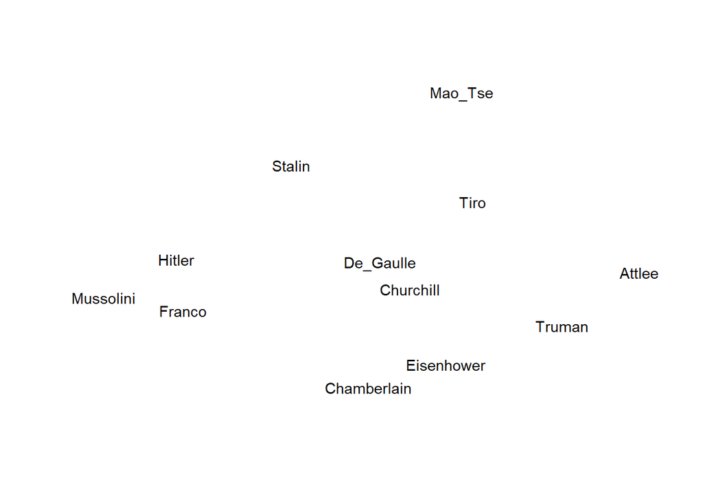

```r
plot(coord_nmmds$points, type = "n", xlab = "", ylab = "", axes = FALSE,)
text(coord_nmmds$points, labels(ww_data), cex = 0.9, xpd = TRUE)
```

Berdasarkan plot di atas kita dapat melihat bahwa “Franco” dan “Mussolini” memiliki kemiripan yang paling banyak dibandingkan dengan yang lain. Jelas bahwa “Hitler” dan “Mussolini” memiliki kesamaan tertinggi kedua. Selanjutnya kita dapat menemukan adanya kesamaan antara “De Gaulle” dan “Churchill”. Sebaliknya “Mussolini” dan “Attlee” memiliki jumlah ketidaksamaan tertinggi berdasarkan plot di atas.

4. **Menghitung nilai STRESS**

```r
stress2 <- seqmds.stress(ww_data, coord_nmmds)
stress2
```

```
## [1] 0.5126911 0.2181888
```

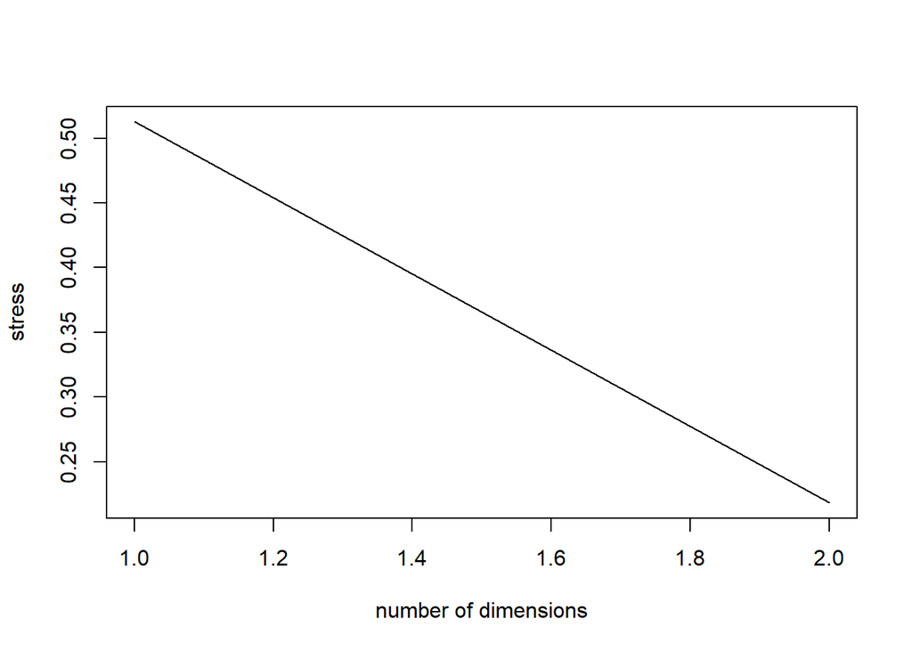

```r
plot(stress2, type='l', xlab='number of dimensions', ylab='stress')
```

Diperoleh dengan pemetaan dua dimensi, nilai stress yang didapatkan sebesar 0.218188.

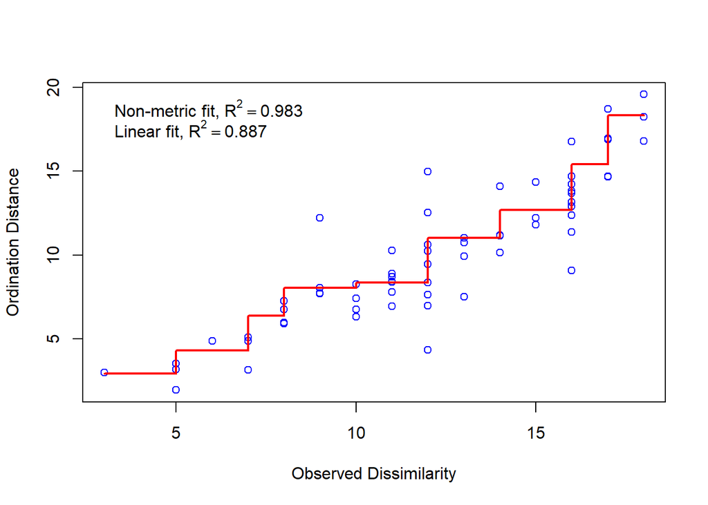

```r
# install.packages("vegan")
library(vegan)
stressplot(coord_nmmds, ww_data)
```

Plot Shepard di atas adalah scatter plot dari jarak antar titik (ada $\frac{n(n-1)}{2}$) vs. ketidaksamaan pada amatan. Yang diharapkan adalah terdapat linieritas antara meningkatnya nilai jarak dengan *dissimilarity*, dan berdasarkan plot di atas diperoleh bahwa terdapat hubungan linier antar keduanya, artinya pemetaan yang dihasilkan sudah baik.